# Characterizing Salmon Shed Tank Temperature, Conductivity, and Water Chemistry

Hello World

Author: OA Lab, NWFSC Title: Salmon Shed Tanks Date: 2018-2019 (R document January 2021)

# Libraries

### 1.) Setting Working Directory

### 2.) Creating the Dataframe

```
## [1] 381  16
```

Dataframes mentioned throughout the document dtank = SPEC sourced data dtankUDA= UDA sourced

SPECCNDCT conductivity measurements recording for SEPC UDACNDCT conductivity measurements recording from Honeywell UDA probe

### 3.) Creating dateTime objects

First Observation recorded as of August 10th 2018

### 4.) Creating Treatments

### 5.) Timeseries Plots

#### 5.1) Salinity Plots

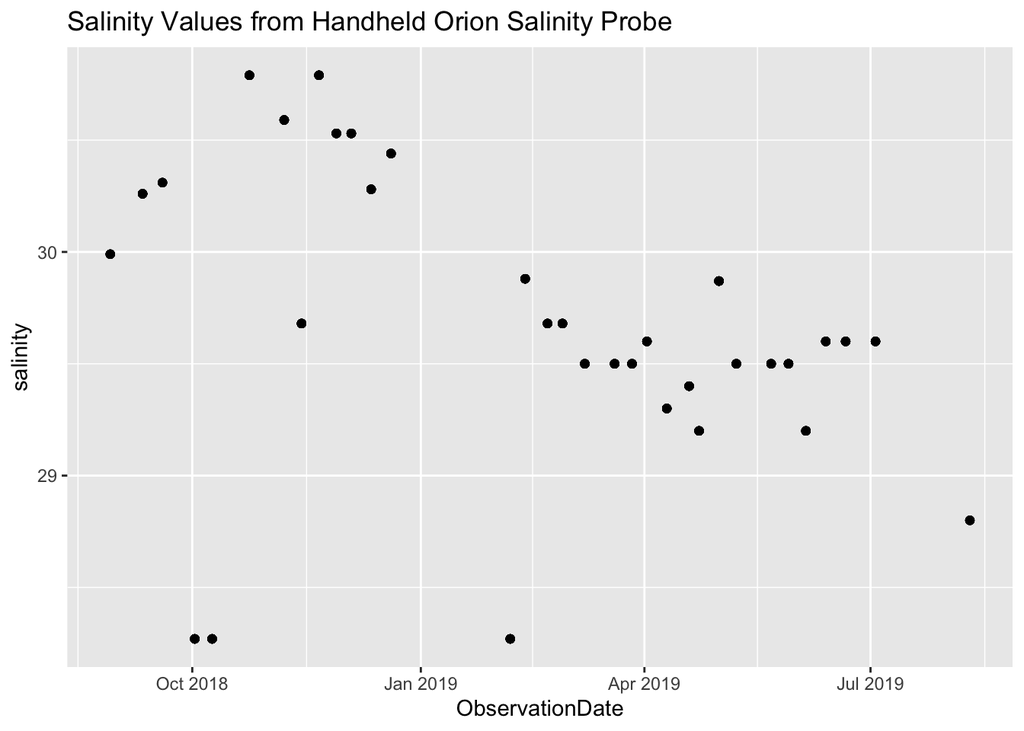

#### 5.1a) Merging salinity data for plots

```
## [1] 277  14
```

```
##  [1] "Date"            "T4.pH"           "T4.temp"         "T3.pH"
##  [5] "T3.temp"         "T5.pH"           "T5.temp"         "T6.pH"
##  [9] "T6.temp"         "T2.pH"           "T2.temp"         "T1.pH"
## [13] "T1.temp"         "Salinity"        "ObservationDate"
```

Determine if salinity units are both PSU

#### 5.1b) Different Salinity Probes’ Data

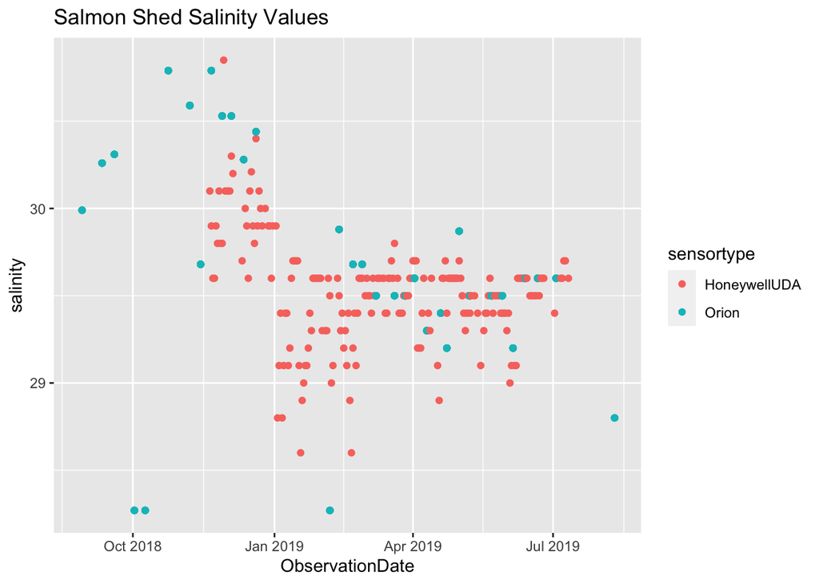

#### 5.2) pH plots per tank timeseries

#### 5.2a) pH plots -Timeseries Plots - UDA

```
## [1] "experiment"  "unit"        "unit_number" "date"        "pH"
## [6] "temp"
```

```
## [1] "experiment"  "unit"        "unit_number" "date"        "pH"
## [6] "temp"        "sensortype"
```

```
## [1] "experiment"      "unit"            "unit_number"     "date"
## [5] "pH"              "temp"            "sensortype"      "ObservationDate"
```

#### 5.2a) pH plots -Timeseries Plots - UDA sensor log filtered

```
## [1] "experiment"      "unit"            "unit_number"     "date"
## [5] "pH"              "temp"            "sensortype"      "ObservationDate"
```

```
## [1] "unit_number"     "pH"              "sensortype"      "ObservationDate"
## [5] "treatment"
```

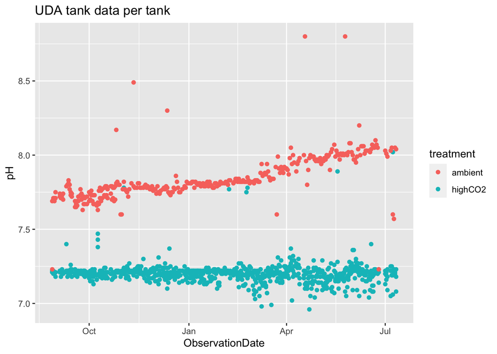

#### 5.3a) UDA tank data per tank (Tank 5 Early Problem Start Relay Problems) (Filtered 5-10 pH)

Tank 5 has early problem start problems (Data from Honeywell UDA sensor & display)

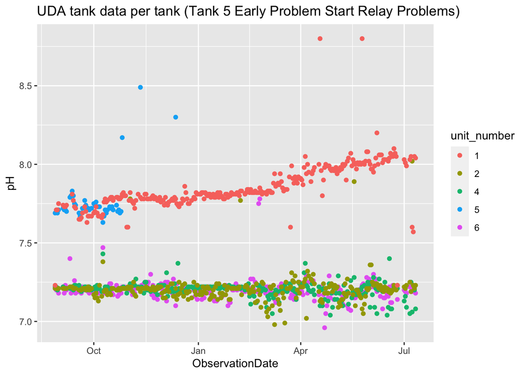

#### 5.3b) UDA tank data per tank (Filtered to show 6-8 pH)

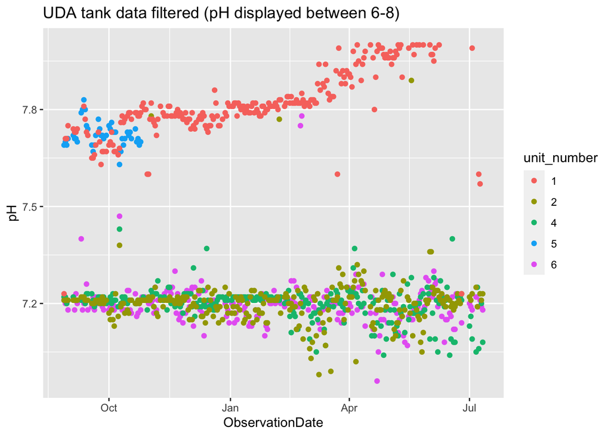

Appears that all Probes got “tired” after April Tank 01’s probe experienced exceptional drift

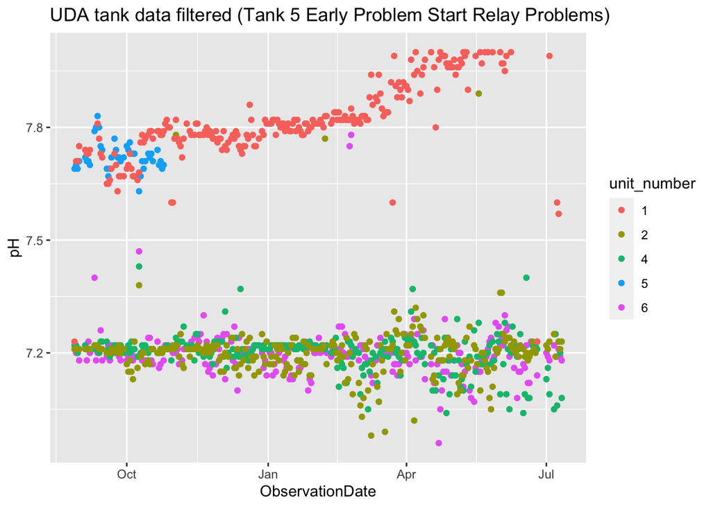

#### 5.4a) pH plots -Timeseries Plots - SPEC data

```
##  [1] "experiment"      "unit"            "unit_number"     "id_1"
##  [5] "id_2"            "id_3"            "time"            "date"
##  [9] "salinity"        "pHat25"          "fileName"        "unit_ID"
## [13] "alk"             "insituTemp"      "pHinsitu"        "dateString"
## [17] "ObservationDate" "treatment"
```

```
## [1] "unit_number"     "pHat25"          "ObservationDate" "treatment"
```

```
## [1] "unit_number"     "pH"              "ObservationDate" "treatment"
```

```
## [1] 1766    5
```

```
## [1] "unit_number"     "pH"              "ObservationDate" "treatment"
## [5] "sensortype"
```

#### 5.4b Water Chemistry Plots between different probe types

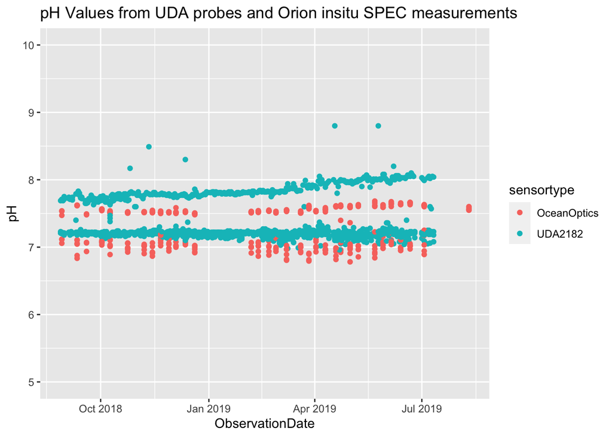

```r
pHplot1 <- ggplot(pHtanklog, aes(x=ObservationDate, y=pH)) +
  geom_point(aes(colour=sensortype, point=)) +
  ylim(5,10) +
  ggtitle("pH Values from UDA probes and Orion insitu SPEC measurements")
pHplot1
```

#### 5.5c Water Chemistry Plots between different treatment timeseries

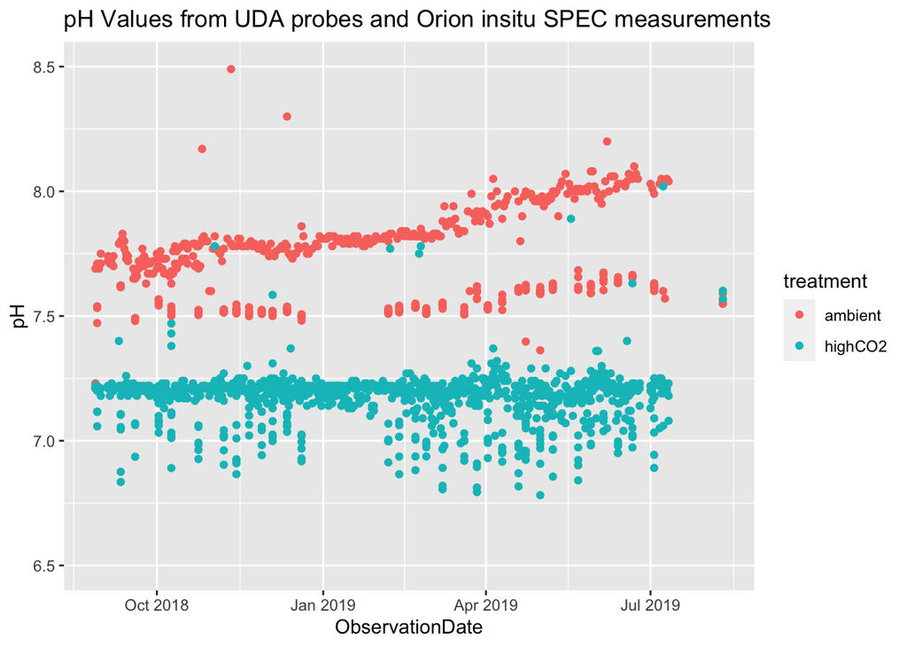

```r
pHplot2 <- ggplot(pHtanklog, aes(x=ObservationDate, y=pH)) +
  geom_point(aes(colour=treatment, point=)) +
  ylim(6.5,8.5) +
  ggtitle("pH Values from UDA probes and Orion insitu SPEC measurements")
pHplot2
```

# Executive Summary

UDA sensors for ambient tank 01 appears to experience significant drift April and beyond. Chase’s UDA data could confirm if pH drift was actual, was a real world seasonal effect SPEC data confirms the High CO2 treatment target pH.

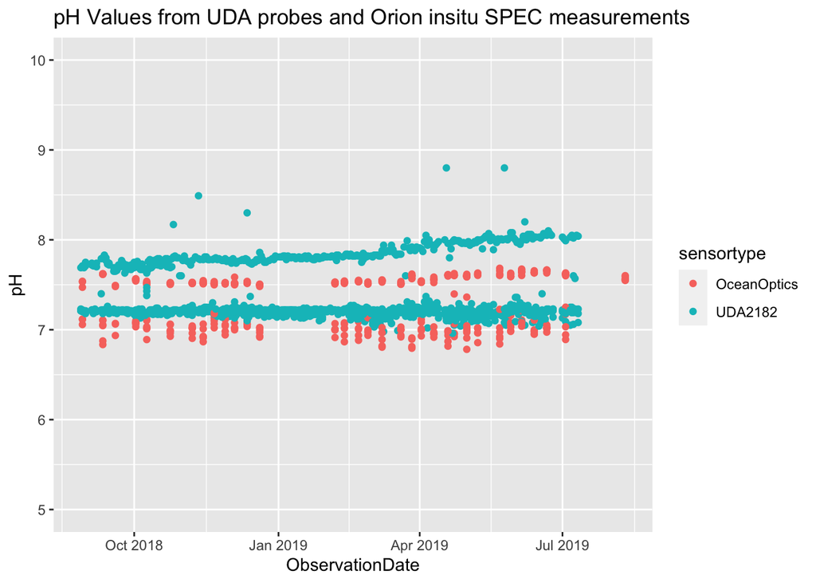

```r
pHplot1
```

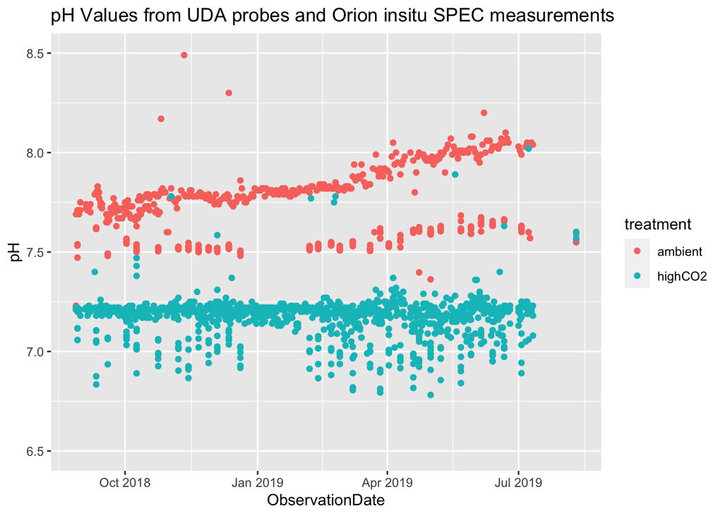

```r
pHplot2
```

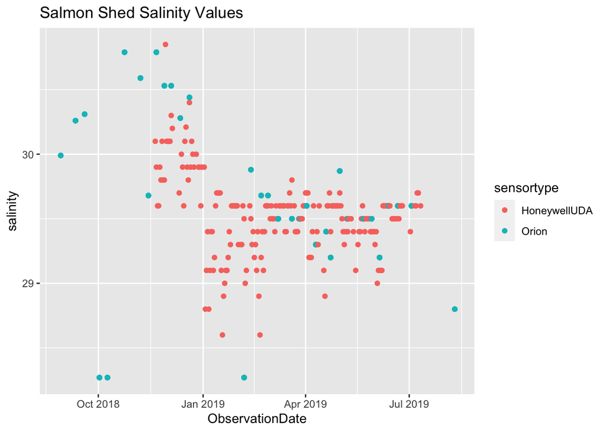

```r
PSUplot
```

```r
pHtanklog.summary <- pHtanklog %>% group_by(treatment, sensortype) %>%
  dplyr::summarize(sd = sd(pH, na.rm = TRUE),
            mean = mean(pH, na.rm = TRUE),
            median = median(pH, na.rm = TRUE),
            IQR = IQR(pH, na.rm = TRUE),
            n = n()) %>%
  mutate(se = sd/sqrt(n)) %>%
  mutate(ci = se*1.96)
write.csv(pHtanklog.summary, "2021.01.08_pHtanklog.summary.csv")
kable(pHtanklog.summary, digits = 4)
```

| treatment | sensortype | sd | mean | median | IQR | n | se | ci |
| --- | --- | --- | --- | --- | --- | --- | --- | --- |
| ambient | OceanOptics | 0.0539 | 7.5589 | 7.5398 | 0.0878 | 190 | 0.0039 | 0.0077 |
| ambient | UDA2182 | 2.0751 | 8.2560 | 7.8100 | 0.2400 | 554 | 0.0882 | 0.1728 |
| highCO2 | OceanOptics | 0.1276 | 7.0254 | 7.0152 | 0.1121 | 191 | 0.0092 | 0.0181 |
| highCO2 | UDA2182 | 0.2469 | 7.2095 | 7.2100 | 0.0400 | 831 | 0.0086 | 0.0168 |

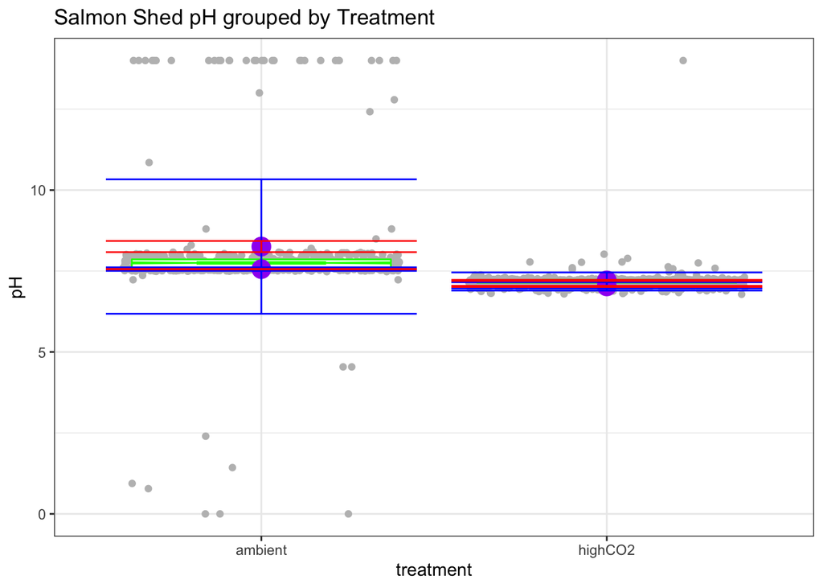

```r
pHboxplots1 <- ggplot(pHtanklog, aes(treatment, pH)) +
            geom_jitter(color = "grey") +
            geom_boxplot(notch = TRUE, outlier.shape = NA, colour = "green") +
            geom_point(data = pHtanklog.summary, aes(x=treatment, y=mean), size=5, color = "purple") +
            geom_errorbar(data = pHtanklog.summary,
                          aes(x=treatment, y=mean, ymin = mean-sd, ymax = mean+sd),
                          color = "blue") +
            geom_errorbar(data = pHtanklog.summary,
                          aes(x=treatment, y=mean, ymin = mean-ci, ymax = mean+ci),
                          colour = "red") +
            # facet_wrap(~TrialID) +
            ggtitle("Salmon Shed pH grouped by Treatment") +
            theme_bw()

pHboxplots1
```

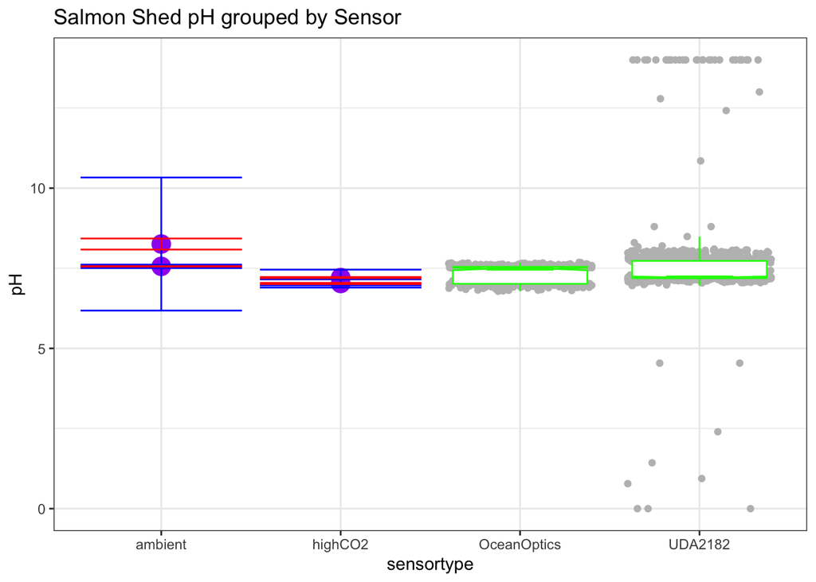

```r
pHboxplots2 <- ggplot(pHtanklog, aes(sensortype, pH)) +
            geom_jitter(color = "grey") +
            geom_boxplot(notch = TRUE, outlier.shape = NA, colour = "green") +
            geom_point(data = pHtanklog.summary, aes(x=treatment, y=mean), size=5, color = "purple") +
            geom_errorbar(data = pHtanklog.summary,
                          aes(x=treatment, y=mean, ymin = mean-sd, ymax = mean+sd),
                          color = "blue") +
            geom_errorbar(data = pHtanklog.summary,
                          aes(x=treatment, y=mean, ymin = mean-ci, ymax = mean+ci),
                          colour = "red") +
            # facet_wrap(~TrialID) +
            ggtitle("Salmon Shed pH grouped by Sensor") +
            theme_bw()

pHboxplots2
```

```r
#**************E*N*D*************#
#*********************************
## END OF SCRIPT | END OF DOCUMENT
#*********************************
```

## END OF SCRIPT | END OF DOCUMENT